# Logistic Regression & Non-linear Effects

## Preface

### R packages

In this practical, we use the R package **effects**. It can be installed by running the following syntax:

```r
install.packages("effects")
```

### Dataset

For this practical, we will use the **pbc** dataset on Primary Biliary Cholangitis from the package **survival**.

You can either load the **survival** package to get access to this dataset

```r
library(survival)
```

or make a copy of this data

```r
pbc <- survival::pbc
```

The **pbc** data contain (among others) the following variables:

```r
str(pbc[, c(5:11, 20)])
```

```
## 'data.frame':    418 obs. of  8 variables:
##  $ age    : num  58.8 56.4 70.1 54.7 38.1 ...
##  $ sex    : Factor w/ 2 levels "m","f": 2 2 1 2 2 2 2 2 2 2 ...
##  $ ascites: int  1 0 0 0 0 0 0 0 0 1 ...
##  $ hepato : int  1 1 0 1 1 1 1 0 0 0 ...
##  $ spiders: int  1 1 0 1 1 0 0 0 1 1 ...
##  $ edema  : num  1 0 0.5 0.5 0 0 0 0 0 1 ...
##  $ bili   : num  14.5 1.1 1.4 1.8 3.4 0.8 1 0.3 3.2 12.6 ...
##  $ stage  : int  4 3 4 4 3 3 3 3 2 4 ...
```

The relevant variables are

- `age`: patient’s age in years
- `sex`: patient’s sex
- `ascites`: presence of ascites
- `spiders`: presence of blood vessel malformations in the skin
- `bili`: serum bilirubin
- `stage`: histologic stage of the disease

## Fitting a Logistic Regression

We want to fit a logistic regression model for the outcome `spiders` using the covariates `age`, `sex`, `bili`, `stage` and `ascites`.

### Variable coding

#### Task 1

Are the variables coded correctly? If not, re-code them.

Three of the variables of interest are coded as integer.

#### Solution 1

The variables `ascites`, `spiders` and `stage` are coded as integer. Both `ascites` and `spiders` do only have two levels, therefore we *could* use them as they are:

```r
table(pbc$spiders, exclude = NULL)
```

```
##
##    0    1 <NA>
##  222   90  106
```

```r
table(pbc$ascites, exclude = NULL)
```

```
##
##    0    1 <NA>
##  288   24  106
```

```r
#  In this case optional:
pbc$spiders <- factor(pbc$spiders)
pbc$ascites <- factor(pbc$ascites)
```

`stage` has four levels and should be re-coded as a factor:

```r
table(pbc$stage, exclude = NULL)
```

```
##
##    1    2    3    4 <NA>
##   21   92  155  144    6
```

```r
pbc$stage <- factor(pbc$stage)
```

#### Task 2

Fit the logistic model described above and get the model summary.

A logistic regression model is a GLM.

You need to specify the model `formula`, the `data` and the `family`.

#### Solution 2

```r
mod1 <- glm(spiders ~ age + sex + bili + stage + ascites, data = pbc,
            family = binomial())
summary(mod1)
```

```
##
## Call:
## glm(formula = spiders ~ age + sex + bili + stage + ascites, family = binomial(),
##     data = pbc)
##
## Deviance Residuals:
##     Min       1Q   Median       3Q      Max
## -1.7728  -0.7471  -0.5353   0.9351   2.3718
##
## Coefficients:
##             Estimate Std. Error z value Pr(>|z|)
## (Intercept) -2.93568    1.36930  -2.144  0.03204 *
## age         -0.02051    0.01410  -1.455  0.14577
## sexf         1.21276    0.57295   2.117  0.03429 *
## bili         0.09867    0.03109   3.174  0.00151 **
## stage2       0.65103    1.10384   0.590  0.55533
## stage3       1.37092    1.06306   1.290  0.19719
## stage4       2.27858    1.06739   2.135  0.03278 *
## ascites1     0.26188    0.53826   0.487  0.62659
## ---
## Signif. codes:  0 '***' 0.001 '**' 0.01 '*' 0.05 '.' 0.1 ' ' 1
##
## (Dispersion parameter for binomial family taken to be 1)
##
##     Null deviance: 374.88  on 311  degrees of freedom
## Residual deviance: 321.27  on 304  degrees of freedom
##   (106 observations deleted due to missingness)
## AIC: 337.27
##
## Number of Fisher Scoring iterations: 5
```

#### Task 3

Investigate the output of the model summary.

- Were there missing values in the data? What happened with those cases?
- What is the interpretation of the coefficient for `bili` in this model?
- What is the interpretation of the coefficients for `stage`?

#### Solution 3

**Missing values:**  
In the lower part of the output of the model summary we can read:

```
## [...]
##      Null deviance: 374.88  on 311  degrees of freedom
##  Residual deviance: 321.27  on 304  degrees of freedom
##    (106 observations deleted due to missingness)
##  AIC: 337.27
##  [...]
```

There were 106 cases with missing values. These were excluded from the analysis.

**Interpretation of the effect of `bili`:**

```
## Coefficients:
##              Estimate Std. Error z value Pr(>|z|)
##  [...]
##  bili         0.09867    0.03109   3.174  0.00151 **
##  [...]
```

With every 1 unite increase of `bili` the expected log odds of having `spiders`, i.e., $\log\left(\frac{P(\texttt{spiders = 1})}{1 - P(\texttt{spiders=1})}\right)$, increases by $\beta_{\texttt{bili}} = 0.099$ (while all other covariates in the model are kept constant).

This means that the odds ratio of `bili` is $\exp(\beta_{\texttt{bili}}) = \exp(0.099) = 1.104$.

**Interpretation of the effect(s) of `stage`:**

```
## Coefficients:
##              Estimate Std. Error z value Pr(>|z|)
##  [...]
##  stage2       0.65103    1.10384   0.590  0.55533
##  stage3       1.37092    1.06306   1.290  0.19719
##  stage4       2.27858    1.06739   2.135  0.03278 *
##  [...]
```

A patient with `stage = 2` has a $\beta_{\texttt{stage2}} = 0.651$ higher log odds to have `spiders` than a patient with `stage = 1` (and the same values for all other covariates).  
The odds ratio of `stage = 2` is $\exp(\beta_{\texttt{stage2}}) = \exp(0.651) = 1.918$.

Patients with `stage = 3` or `stage = 4` have a $\beta_{\texttt{stage3}} = 1.371$ and $\beta_{\texttt{stage4}} = 2.279$ higher log odds to have `spiders` than a patient with `stage = 1` (who has the same values for all other covariates).  
The corresponding odds ratios of `stage = 3` and `stage = 4` are $\exp(\beta_{\texttt{stage3}}) = \exp(1.371) = 3.939$ and $\exp(\beta_{\texttt{stage4}}) = \exp(2.279) = 9.763$, respectively.

### Comparing Models

We would like to know if the variable `stage` has a significant/relevant contribution to the model.

#### Task 1

How can we determine this? Does the output of the `summary()` give us an answer?

#### Solution 1

Since `stage` is a factor with >2 levels, multiple dummy variables are used in the model. To answer the question whether `stage` has a significant/relevant contribution we need to consider all three dummy variables simultaneously.

Therefore, we need to compare `mod1` with the model in which `stage` was removed.

#### Task 2

Re-fit `mod1` without `stage` (but give it a different name).

#### Solution 2

```r
mod1b <- glm(spiders ~ age + sex + bili + ascites, data = pbc,
             family = binomial())

# We could also use:
mod1b <- update(mod1, formula = . ~ . - stage)
```

Note:

The function `update()` allows us to update models or formulas.

- To update a model, specify the new values for those arguments that change.
- To update a formula, we can use the `.` to say ‘as it was’ and only add the change.

#### Task 3

- Are the models `mod1` and `mod1b` nested or not?
- Which method can we use to compare them?
- Perform this comparison and interpret the result.

#### Solution 3

The models are nested. `mod1b` is a specific case of `mod1` for which $\beta_{\texttt{stage2}} = \beta_{\texttt{stage3}} = \beta_{\texttt{stage4}} = 0$

To compare nested models, we can use a likelihood ratio test:

```r
anova(mod1, mod1b, test = 'LRT')
```

```
## Analysis of Deviance Table
##
## Model 1: spiders ~ age + sex + bili + stage + ascites
## Model 2: spiders ~ age + sex + bili + ascites
##   Resid. Df Resid. Dev Df Deviance Pr(>Chi)
## 1       304     321.27
## 2       307     342.65 -3   -21.38 8.78e-05 ***
## ---
## Signif. codes:  0 '***' 0.001 '**' 0.01 '*' 0.05 '.' 0.1 ' ' 1
```

The small p-value indicates that the observed difference in residual deviance between the two models would be very unlikely to observe if `mod1b` was the correct model.

Hence, the model with `stage` fits the data better.

## Non-linear effects

We now want to investigate if the continuous variables have non-linear effect.

### Task 1

To do this, use a natural cubic splines with three degrees of freedom.

Use the function `ns()` from the package `splines`.

### Solution 1

```r
library("splines")
mod2 <- glm(spiders ~ ns(age, df = 3) + sex + ns(bili, df = 3) + stage + ascites,
            data = pbc, family = binomial())

summary(mod2)
```

```
##
## Call:
## glm(formula = spiders ~ ns(age, df = 3) + sex + ns(bili, df = 3) +
##     stage + ascites, family = binomial(), data = pbc)
##
## Deviance Residuals:
##     Min       1Q   Median       3Q      Max
## -1.5599  -0.7723  -0.4592   0.9689   2.4957
##
## Coefficients:
##                   Estimate Std. Error z value Pr(>|z|)
## (Intercept)        -4.9676     1.4427  -3.443 0.000575 ***
## ns(age, df = 3)1   -0.5062     0.6187  -0.818 0.413253
## ns(age, df = 3)2   -0.2193     1.8429  -0.119 0.905292
## ns(age, df = 3)3   -0.4484     1.0426  -0.430 0.667141
## sexf                1.4727     0.5869   2.509 0.012098 *
## ns(bili, df = 3)1   1.9401     0.8638   2.246 0.024699 *
## ns(bili, df = 3)2   4.5549     1.2426   3.666 0.000247 ***
## ns(bili, df = 3)3   2.2240     1.1900   1.869 0.061642 .
## stage2              0.3438     1.1180   0.308 0.758447
## stage3              0.9110     1.0815   0.842 0.399585
## stage4              1.6438     1.0919   1.506 0.132190
## ascites1            0.2423     0.5394   0.449 0.653314
## ---
## Signif. codes:  0 '***' 0.001 '**' 0.01 '*' 0.05 '.' 0.1 ' ' 1
##
## (Dispersion parameter for binomial family taken to be 1)
##
##     Null deviance: 374.88  on 311  degrees of freedom
## Residual deviance: 310.91  on 300  degrees of freedom
##   (106 observations deleted due to missingness)
## AIC: 334.91
##
## Number of Fisher Scoring iterations: 5
```

### Task 2

What is the interpretation of the regression coefficients for `bili` in `mod2`?

### Solution 2

The coefficients tell us how much each of the basis functions of the splines have been scaled. They do not have a direct meaningful clinical interpretation.

### Visualization

To visualize the resulting non-linear fit, we can use an effect plot.

The idea is to obtain fitted values for a specific set of cases, which vary in the value of the covariate of interest, but have constant values for all other covariates.

The R package **effects** can help us in creating such plots:

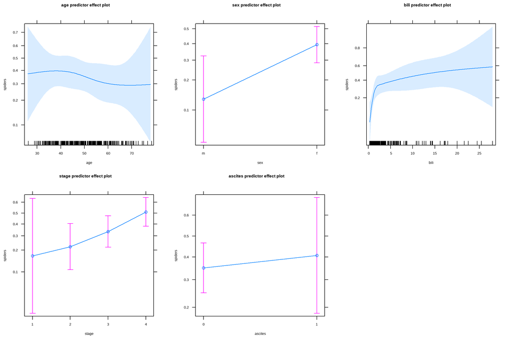

```r
# if not installed, run:
# install.packages("effects")

library("effects")
plot(predictorEffects(mod2))
```

From the **effects** package documentation:

> […] the vertical axis is in linear predictor scale, which is the log-odds or logit for this logistic regression example, but the vertical axis labels are in mean (probability) scale, so the tick-marks are not equally spaced

The plot for `age`, for example, shows us the estimated probability (and corresponding 95% confidence band) for having `spiders` for any given `age` while the other variables have been fixed to the population mean.

For a more information about the **effects** package and its functions, please refer to the reference manual and vignettes available at https://CRAN.R-project.org/package=effects.

### Task 3

The effect plots show that the effect of `age` is quite linear, but that the effect of `bili` is indeed non-linear.

Confirm that the non-linear effect for `age` is not needed, i.e., does not fit the data better than the corresponding model with a linear effect of `age`.

Re-fit the model and replace the spline for `age` with just `age` to compare the model fit.

For the comparison, use the `AIC()` or `BIC()`.

### Solution 3

```r
mod2b <- glm(spiders ~ age + sex + ns(bili, df = 3) + stage + ascites,
             data = pbc, family = binomial())
```

When comparing models with regards to the effect of a variable that is modelled using a spline, models are usually not nested (except in specific cases). Therefore, we will use here the information criteria to compare `mod2` and `mod2b`:

```r
BIC(mod2, mod2b)
```

```
##       df      BIC
## mod2  12 379.8257
## mod2b 10 368.5101
```

We see that the smaller (less degrees of freedom / parameters) model has the lower BIC. This confirms that the spline specification for `age` is not necessary.

### Task 4

The non-linear association for `bili` resembles the shape of the logarithmic function.

Investigate if we can replace the spline for `bili` with the (natural) logarithm.

- using information criteria
- visually

For the visual comparison, the function `predictorEffect(predictor = "bili", mod = <name of model>)` may be useful if you want to show the effect plot for the variable `bili` only.

### Solution 4

```r
mod2c <- glm(spiders ~ age + sex + log(bili) + stage + ascites,
             data = pbc, family = binomial())
```

```r
BIC(mod2b, mod2c)
```

```
##       df      BIC
## mod2b 10 368.5101
## mod2c  8 358.4755
```

The BIC shows that the model with `log(bili)` has better model fit.

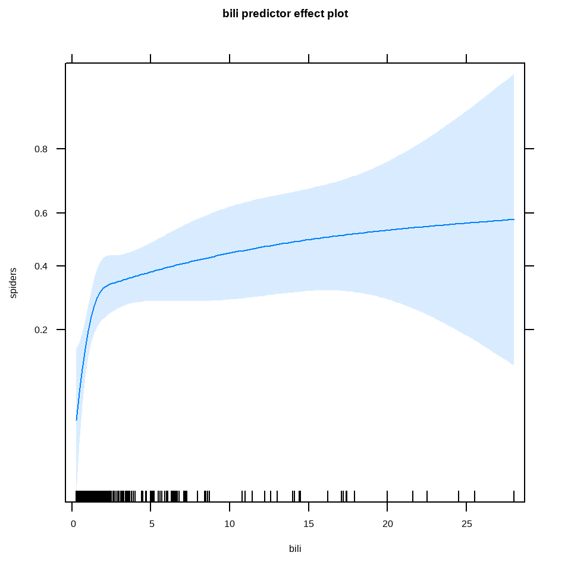

```r
plot(predictorEffect('bili', mod2b))
```

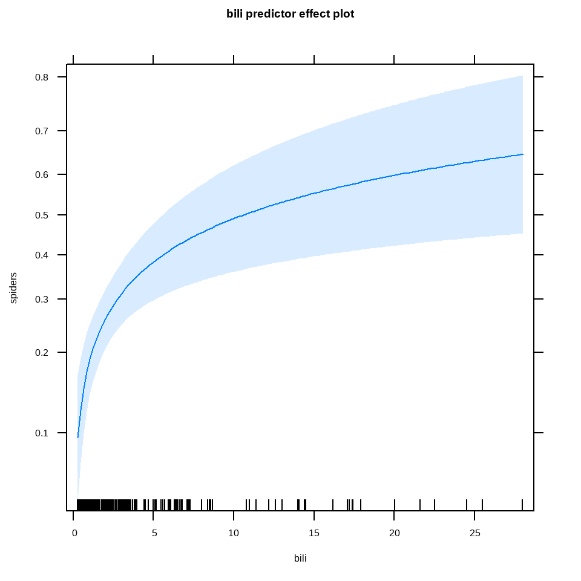

```r
plot(predictorEffect('bili', mod2c))
```

## Additional Exercises

### Ordinal Covariate

The variable `stage` is actually ordinal, but when we re-coded it above, we did not consider that.

#### Task 1

Make an ordered factor from `stage` and call the new variable `stage_ord`.

#### Solution 1

```r
pbc$stage_ord <- as.ordered(pbc$stage)

# or alternatively:
# pbc$stage_ord <- factor(pbc$stage, ordered = TRUE)
```

Note:

R automatically orders factors by their level (alphabetically or by number):

```r
factor(c('low', 'medium', 'high'), ordered = TRUE)
```

```
## [1] low    medium high
## Levels: high < low < medium
```

For ordered factors where the levels should not be ordered by alphabet (or number) you need to specify the `levels` in `factor()`:

```r
factor(c('low', 'medium', 'high'), levels = c('low', 'medium', 'high'), ordered = TRUE)
```

```
## [1] low    medium high
## Levels: low < medium < high
```

#### Task 2

- Fit another version of `mod1` using `stage_ord` instead of `stage`.  
  Do not copy-paste the syntax from above, but use `update()` to change the model.
- What is the interpretation of the regression coefficients for `stage_ord`?

#### Solution 2

To update `mod1`, we need to specify that we want to change the `formula`. We remove the original `stage` and add `stage_ord`:

```r
mod1c <- update(mod1, formula = . ~ . -stage + stage_ord)
summary(mod1c)
```

```
##
## Call:
## glm(formula = spiders ~ age + sex + bili + ascites + stage_ord,
##     family = binomial(), data = pbc)
##
## Deviance Residuals:
##     Min       1Q   Median       3Q      Max
## -1.7728  -0.7471  -0.5353   0.9351   2.3718
##
## Coefficients:
##             Estimate Std. Error z value Pr(>|z|)
## (Intercept) -1.86055    0.98226  -1.894  0.05821 .
## age         -0.02051    0.01410  -1.455  0.14577
## sexf         1.21276    0.57295   2.117  0.03429 *
## bili         0.09867    0.03109   3.174  0.00151 **
## ascites1     0.26188    0.53826   0.487  0.62659
## stage_ord.L  1.68949    0.72208   2.340  0.01930 *
## stage_ord.Q  0.12831    0.57199   0.224  0.82250
## stage_ord.C  0.02659    0.37473   0.071  0.94343
## ---
## Signif. codes:  0 '***' 0.001 '**' 0.01 '*' 0.05 '.' 0.1 ' ' 1
##
## (Dispersion parameter for binomial family taken to be 1)
##
##     Null deviance: 374.88  on 311  degrees of freedom
## Residual deviance: 321.27  on 304  degrees of freedom
##   (106 observations deleted due to missingness)
## AIC: 337.27
##
## Number of Fisher Scoring iterations: 5
```

The summary of the coefficients for `stage_ord` looks a bit different than the corresponding part in `mod1`. We now have:

```
## Coefficients:
## [...]
## stage_ord.L  1.68949    0.72208   2.340  0.01930 *
## stage_ord.Q  0.12831    0.57199   0.224  0.82250
## stage_ord.C  0.02659    0.37473   0.071  0.94343
## [...]
```

where in `mod1` we had:

```
## Coefficients:
## [...]
## stage2       0.65103    1.10384   0.590  0.55533
## stage3       1.37092    1.06306   1.290  0.19719
## stage4       2.27858    1.06739   2.135  0.03278 *
## [...]
```

When R creates dummy variables, the factor levels are added at the end of the variable name. For ordered factors, R uses by default **orthogonal polynomials**, i.e., in this case a **l**inear, a **q**uadratic and a **c**ubic term.

You can obtain the coding for the (ordered) factor using `contrasts()`:

```r
contrasts(pbc$stage_ord)
```

```
##              .L   .Q         .C
## [1,] -0.6708204  0.5 -0.2236068
## [2,] -0.2236068 -0.5  0.6708204
## [3,]  0.2236068 -0.5 -0.6708204
## [4,]  0.6708204  0.5  0.2236068
```

These values are values from a linear, quadratic and cubic curve at the numeric values of the factor levels:

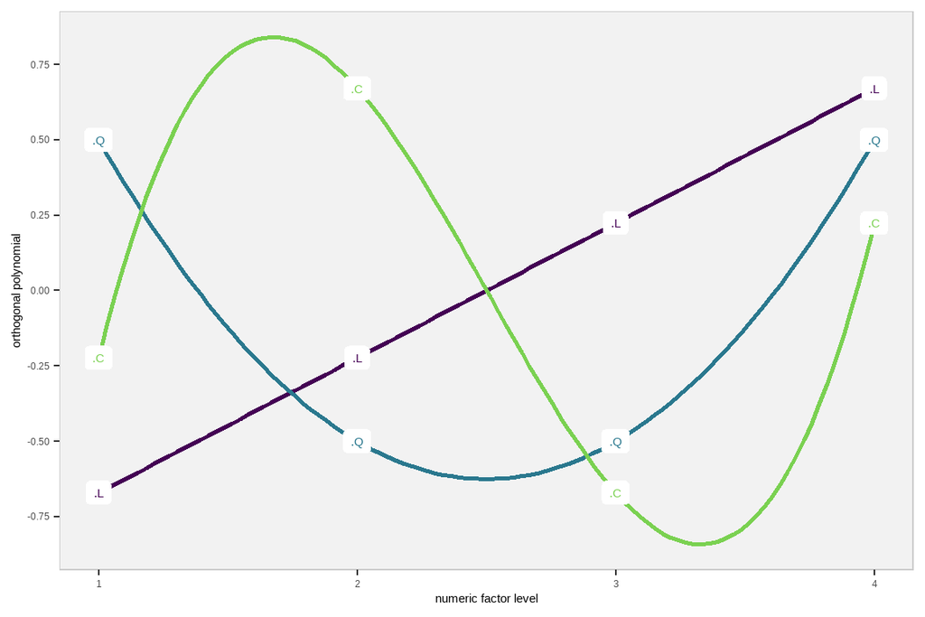

The coefficients in the `summary()` output are thus the effect estimates for these linear, quadratic and cubic curves and **cannot be interpreted as difference from a reference category** like it was the case with a dummy coded factor.

© Nicole Erler